# Part I - (Exploration de Loan Data from Prosper )

## Introduction

> Cet dataset contient 113 937 prêts avec 81 variables sur chaque prêt, y compris le montant du prêt, le taux de l'emprunteur (ou taux d'intérêt), le statut actuel du prêt, le revenu de l'emprunteur et bien d'autres. La description des données [ICI](https://docs.google.com/spreadsheets/d/1gDyi_L4UvIrLTEC6Wri5nbaMmkGmLQBk-Yx3z0XDEtI/edit#gid=0)

## Preliminary Wrangling

```python
# import all packages and set plots to be embedded inline
import numpy as np
import pandas as pd
import matplotlib.pyplot as plt
import seaborn as sb

%matplotlib inline
```

```python
prop_loan=pd.read_csv('prosperLoanData.csv.')

# option pour pouvoir observer toutes les colonnes sans rupture
pd.set_option('display.max_columns', None)
prop_loan.head()
```

|  | ListingKey | ListingNumber | ListingCreationDate | CreditGrade | Term | LoanStatus | ClosedDate | BorrowerAPR | BorrowerRate | LenderYield | EstimatedEffectiveYield | EstimatedLoss | EstimatedReturn | ProsperRating (numeric) | ProsperRating (Alpha) | ProsperScore | ListingCategory (numeric) | BorrowerState | Occupation | EmploymentStatus | EmploymentStatusDuration | IsBorrowerHomeowner | CurrentlyInGroup | GroupKey | DateCreditPulled | CreditScoreRangeLower | CreditScoreRangeUpper | FirstRecordedCreditLine | CurrentCreditLines | … |
| --- | --- | --- | --- | --- | --- | --- | --- | --- | --- | --- | --- | --- | --- | --- | --- | --- | --- | --- | --- | --- | --- | --- | --- | --- | --- | --- | --- | --- | --- | --- |
| 0 | 1021339766868145413AB3B | 193129 | 2007-08-26 19:09:29.263000000 | C | 36 | Completed | 2009-08-14 00:00:00 | 0.16516 | 0.1580 | 0.1380 | NaN | NaN | NaN | NaN | NaN | NaN | 0 | CO | Other | Self-employed | 2.0 | True | True | NaN | 2007-08-26 18:41:46.780000000 | 640.0 | 659.0 | 2001-10-11 00:00:00 | 5.0 | … |
| 1 | 10273602499503308B223C1 | 1209647 | 2014-02-27 08:28:07.900000000 | NaN | 36 | Current | NaN | 0.12016 | 0.0920 | 0.0820 | 0.07960 | 0.0249 | 0.05470 | 6.0 | A | 7.0 | 2 | CO | Professional | Employed | 44.0 | False | False | NaN | 2014-02-27 08:28:14 | 680.0 | 699.0 | 1996-03-18 00:00:00 | 14.0 | … |
| 2 | 0EE9337825851032864889A | 81716 | 2007-01-05 15:00:47.090000000 | HR | 36 | Completed | 2009-12-17 00:00:00 | 0.28269 | 0.2750 | 0.2400 | NaN | NaN | NaN | NaN | NaN | NaN | 0 | GA | Other | Not available | NaN | False | True | 783C3371218786870A73D20 | 2007-01-02 14:09:10.060000000 | 480.0 | 499.0 | 2002-07-27 00:00:00 | NaN | … |
| 3 | 0EF5356002482715299901A | 658116 | 2012-10-22 11:02:35.010000000 | NaN | 36 | Current | NaN | 0.12528 | 0.0974 | 0.0874 | 0.08490 | 0.0249 | 0.06000 | 6.0 | A | 9.0 | 16 | GA | Skilled Labor | Employed | 113.0 | True | False | NaN | 2012-10-22 11:02:32 | 800.0 | 819.0 | 1983-02-28 00:00:00 | 5.0 | … |
| 4 | 0F023589499656230C5E3E2 | 909464 | 2013-09-14 18:38:39.097000000 | NaN | 36 | Current | NaN | 0.24614 | 0.2085 | 0.1985 | 0.18316 | 0.0925 | 0.09066 | 3.0 | D | 4.0 | 2 | MN | Executive | Employed | 44.0 | True | False | NaN | 2013-09-14 18:38:44 | 680.0 | 699.0 | 2004-02-20 00:00:00 | 19.0 | … |

```python
prop_loan.info()
```

```
<class 'pandas.core.frame.DataFrame'>
RangeIndex: 113937 entries, 0 to 113936
Data columns (total 81 columns):
 #   Column                               Non-Null Count   Dtype
---  ------                               --------------   -----
 0   ListingKey                           113937 non-null  object
 1   ListingNumber                        113937 non-null  int64
 2   ListingCreationDate                  113937 non-null  object
 3   CreditGrade                          28953 non-null   object
 4   Term                                 113937 non-null  int64
 5   LoanStatus                           113937 non-null  object
 6   ClosedDate                           55089 non-null   object
 7   BorrowerAPR                          113912 non-null  float64
 8   BorrowerRate                         113937 non-null  float64
 9   LenderYield                          113937 non-null  float64
```

[output cut: 73 more lines]

```python
prop_loan.duplicated().sum()
```

```
0
```

```python
prop_loan.isnull().sum().sort_values(ascending=False)
```

```
GroupKey                         100596
LoanFirstDefaultedCycleNumber     96985
ScorexChangeAtTimeOfListing       95009
ProsperPrincipalOutstanding       91852
ProsperPrincipalBorrowed          91852
                                  ...
IncomeRange                           0
IncomeVerifiable                      0
StatedMonthlyIncome                   0
LoanKey                               0
Investors                             0
Length: 81, dtype: int64
```

```python
prop_loan.describe()
```

|  | ListingNumber | Term | BorrowerAPR | BorrowerRate | LenderYield | EstimatedEffectiveYield | EstimatedLoss | EstimatedReturn | ProsperRating (numeric) | ProsperScore | ListingCategory (numeric) | EmploymentStatusDuration | CreditScoreRangeLower | CreditScoreRangeUpper | CurrentCreditLines | OpenCreditLines | TotalCreditLinespast7years | OpenRevolvingAccounts | OpenRevolvingMonthlyPayment | InquiriesLast6Months | TotalInquiries | CurrentDelinquencies | AmountDelinquent | DelinquenciesLast7Years | PublicRecordsLast10Years | PublicRecordsLast12Months | RevolvingCreditBalance | BankcardUtilization | AvailableBankcardCredit | … |
| --- | --- | --- | --- | --- | --- | --- | --- | --- | --- | --- | --- | --- | --- | --- | --- | --- | --- | --- | --- | --- | --- | --- | --- | --- | --- | --- | --- | --- | --- | --- |
| count | 1.139370e+05 | 113937.000000 | 113912.000000 | 113937.000000 | 113937.000000 | 84853.000000 | 84853.000000 | 84853.000000 | 84853.000000 | 84853.000000 | 113937.000000 | 106312.000000 | 113346.000000 | 113346.000000 | 106333.000000 | 106333.000000 | 113240.000000 | 113937.00000 | 113937.000000 | 113240.000000 | 112778.000000 | 113240.000000 | 106315.000000 | 112947.000000 | 113240.000000 | 106333.000000 | 1.063330e+05 | 106333.000000 | 106393.000000 | … |
| mean | 6.278857e+05 | 40.830248 | 0.218828 | 0.192764 | 0.182701 | 0.168661 | 0.080306 | 0.096068 | 4.072243 | 5.950067 | 2.774209 | 96.071582 | 685.567731 | 704.567731 | 10.317192 | 9.260164 | 26.754539 | 6.96979 | 398.292161 | 1.435085 | 5.584405 | 0.592052 | 984.507059 | 4.154984 | 0.312646 | 0.015094 | 1.759871e+04 | 0.561309 | 11210.225447 | … |
| std | 3.280762e+05 | 10.436212 | 0.080364 | 0.074818 | 0.074516 | 0.068467 | 0.046764 | 0.030403 | 1.673227 | 2.376501 | 3.996797 | 94.480605 | 66.458275 | 66.458275 | 5.457866 | 5.022644 | 13.637871 | 4.63097 | 447.159711 | 2.437507 | 6.429946 | 1.978707 | 7158.270157 | 10.160216 | 0.727868 | 0.154092 | 3.293640e+04 | 0.317918 | 19818.361309 | … |
| min | 4.000000e+00 | 12.000000 | 0.006530 | 0.000000 | -0.010000 | -0.182700 | 0.004900 | -0.182700 | 1.000000 | 1.000000 | 0.000000 | 0.000000 | 0.000000 | 19.000000 | 0.000000 | 0.000000 | 2.000000 | 0.00000 | 0.000000 | 0.000000 | 0.000000 | 0.000000 | 0.000000 | 0.000000 | 0.000000 | 0.000000 | 0.000000e+00 | 0.000000 | 0.000000 | … |
| 25% | 4.009190e+05 | 36.000000 | 0.156290 | 0.134000 | 0.124200 | 0.115670 | 0.042400 | 0.074080 | 3.000000 | 4.000000 | 1.000000 | 26.000000 | 660.000000 | 679.000000 | 7.000000 | 6.000000 | 17.000000 | 4.00000 | 114.000000 | 0.000000 | 2.000000 | 0.000000 | 0.000000 | 0.000000 | 0.000000 | 0.000000 | 3.121000e+03 | 0.310000 | 880.000000 | … |
| 50% | 6.005540e+05 | 36.000000 | 0.209760 | 0.184000 | 0.173000 | 0.161500 | 0.072400 | 0.091700 | 4.000000 | 6.000000 | 1.000000 | 67.000000 | 680.000000 | 699.000000 | 10.000000 | 9.000000 | 25.000000 | 6.00000 | 271.000000 | 1.000000 | 4.000000 | 0.000000 | 0.000000 | 0.000000 | 0.000000 | 0.000000 | 8.549000e+03 | 0.600000 | 4100.000000 | … |
| 75% | 8.926340e+05 | 36.000000 | 0.283810 | 0.250000 | 0.240000 | 0.224300 | 0.112000 | 0.116600 | 5.000000 | 8.000000 | 3.000000 | 137.000000 | 720.000000 | 739.000000 | 13.000000 | 12.000000 | 35.000000 | 9.00000 | 525.000000 | 2.000000 | 7.000000 | 0.000000 | 0.000000 | 3.000000 | 0.000000 | 0.000000 | 1.952100e+04 | 0.840000 | 13180.000000 | … |
| max | 1.255725e+06 | 60.000000 | 0.512290 | 0.497500 | 0.492500 | 0.319900 | 0.366000 | 0.283700 | 7.000000 | 11.000000 | 20.000000 | 755.000000 | 880.000000 | 899.000000 | 59.000000 | 54.000000 | 136.000000 | 51.00000 | 14985.000000 | 105.000000 | 379.000000 | 83.000000 | 463881.000000 | 99.000000 | 38.000000 | 20.000000 | 1.435667e+06 | 5.950000 | 646285.000000 | … |

### Remarque

> Je ne vais m'interresser à toutes les variales du dataset car trop nombreuses et certaines peu pertinantes pour le cas de mon investigation. Ainsi je vais selectionner celle que je juge interressante pour mon investigation.

```python
prop_loan.head()
```

|  | ListingKey | ListingNumber | ListingCreationDate | CreditGrade | Term | LoanStatus | ClosedDate | BorrowerAPR | BorrowerRate | LenderYield | EstimatedEffectiveYield | EstimatedLoss | EstimatedReturn | ProsperRating (numeric) | ProsperRating (Alpha) | ProsperScore | ListingCategory (numeric) | BorrowerState | Occupation | EmploymentStatus | EmploymentStatusDuration | IsBorrowerHomeowner | CurrentlyInGroup | GroupKey | DateCreditPulled | CreditScoreRangeLower | CreditScoreRangeUpper | FirstRecordedCreditLine | CurrentCreditLines | … |
| --- | --- | --- | --- | --- | --- | --- | --- | --- | --- | --- | --- | --- | --- | --- | --- | --- | --- | --- | --- | --- | --- | --- | --- | --- | --- | --- | --- | --- | --- | --- |
| 0 | 1021339766868145413AB3B | 193129 | 2007-08-26 19:09:29.263000000 | C | 36 | Completed | 2009-08-14 00:00:00 | 0.16516 | 0.1580 | 0.1380 | NaN | NaN | NaN | NaN | NaN | NaN | 0 | CO | Other | Self-employed | 2.0 | True | True | NaN | 2007-08-26 18:41:46.780000000 | 640.0 | 659.0 | 2001-10-11 00:00:00 | 5.0 | … |
| 1 | 10273602499503308B223C1 | 1209647 | 2014-02-27 08:28:07.900000000 | NaN | 36 | Current | NaN | 0.12016 | 0.0920 | 0.0820 | 0.07960 | 0.0249 | 0.05470 | 6.0 | A | 7.0 | 2 | CO | Professional | Employed | 44.0 | False | False | NaN | 2014-02-27 08:28:14 | 680.0 | 699.0 | 1996-03-18 00:00:00 | 14.0 | … |
| 2 | 0EE9337825851032864889A | 81716 | 2007-01-05 15:00:47.090000000 | HR | 36 | Completed | 2009-12-17 00:00:00 | 0.28269 | 0.2750 | 0.2400 | NaN | NaN | NaN | NaN | NaN | NaN | 0 | GA | Other | Not available | NaN | False | True | 783C3371218786870A73D20 | 2007-01-02 14:09:10.060000000 | 480.0 | 499.0 | 2002-07-27 00:00:00 | NaN | … |
| 3 | 0EF5356002482715299901A | 658116 | 2012-10-22 11:02:35.010000000 | NaN | 36 | Current | NaN | 0.12528 | 0.0974 | 0.0874 | 0.08490 | 0.0249 | 0.06000 | 6.0 | A | 9.0 | 16 | GA | Skilled Labor | Employed | 113.0 | True | False | NaN | 2012-10-22 11:02:32 | 800.0 | 819.0 | 1983-02-28 00:00:00 | 5.0 | … |
| 4 | 0F023589499656230C5E3E2 | 909464 | 2013-09-14 18:38:39.097000000 | NaN | 36 | Current | NaN | 0.24614 | 0.2085 | 0.1985 | 0.18316 | 0.0925 | 0.09066 | 3.0 | D | 4.0 | 2 | MN | Executive | Employed | 44.0 | True | False | NaN | 2013-09-14 18:38:44 | 680.0 | 699.0 | 2004-02-20 00:00:00 | 19.0 | … |

```python
var_util=['ListingCreationDate','Term','LoanStatus','ClosedDate','BorrowerAPR','BorrowerRate','EstimatedLoss','ProsperRating (numeric)','ProsperRating (Alpha)','ProsperScore','ListingCategory (numeric)','BorrowerState','Occupation','EmploymentStatus','DelinquenciesLast7Years','StatedMonthlyIncome','LoanOriginalAmount','LoanOriginationDate','Recommendations','Investors']
var_util_df=prop_loan[var_util]
var_util_df.sample(10)
```

|  | ListingCreationDate | Term | LoanStatus | ClosedDate | BorrowerAPR | BorrowerRate | EstimatedLoss | ProsperRating (numeric) | ProsperRating (Alpha) | ProsperScore | ListingCategory (numeric) | BorrowerState | Occupation | EmploymentStatus | DelinquenciesLast7Years | StatedMonthlyIncome | LoanOriginalAmount | LoanOriginationDate | Recommendations | Investors |
| --- | --- | --- | --- | --- | --- | --- | --- | --- | --- | --- | --- | --- | --- | --- | --- | --- | --- | --- | --- | --- |
| 21698 | 2012-05-25 16:56:31.300000000 | 36 | Past Due (31-60 days) | NaN | 0.33553 | 0.2958 | 0.1470 | 2.0 | E | 6.0 | 7 | FL | Construction | Employed | 38.0 | 3041.666667 | 4000 | 2012-06-05 00:00:00 | 0 | 31 |
| 88276 | 2012-12-16 19:54:16.503000000 | 36 | Current | NaN | 0.33286 | 0.2932 | 0.1425 | 2.0 | E | 6.0 | 1 | IL | Postal Service | Employed | 12.0 | 5750.000000 | 4000 | 2012-12-26 00:00:00 | 0 | 84 |
| 97546 | 2007-09-02 00:15:28.603000000 | 36 | Completed | 2010-02-01 00:00:00 | 0.29554 | 0.2800 | NaN | NaN | NaN | NaN | 0 | IL | Nurse's Aide | Full-time | 2.0 | 2000.000000 | 3000 | 2007-09-13 00:00:00 | 0 | 55 |
| 50612 | 2013-12-03 16:37:46.960000000 | 60 | Current | NaN | 0.18197 | 0.1585 | 0.0624 | 4.0 | C | 10.0 | 1 | NY | Other | Employed | 0.0 | 7500.000000 | 25000 | 2013-12-12 00:00:00 | 0 | 1 |
| 110514 | 2010-11-20 14:58:59.907000000 | 36 | Completed | 2013-12-03 00:00:00 | 0.13068 | 0.1095 | 0.0350 | 6.0 | A | 9.0 | 1 | KS | Professional | Employed | 0.0 | 5416.666667 | 15000 | 2010-12-03 00:00:00 | 0 | 214 |
| 56605 | 2013-09-03 09:06:43.543000000 | 60 | Current | NaN | 0.26877 | 0.2432 | 0.0975 | 3.0 | D | 2.0 | 1 | NV | Nurse (RN) | Employed | 1.0 | 5000.000000 | 4000 | 2013-09-06 00:00:00 | 0 | 42 |
| 58566 | 2013-07-12 17:13:02.957000000 | 60 | Past Due (61-90 days) | NaN | 0.22693 | 0.2024 | 0.0699 | 4.0 | C | 4.0 | 6 | PA | Skilled Labor | Employed | 69.0 | 5125.000000 | 4500 | 2013-09-05 00:00:00 | 0 | 1 |
| 26627 | 2008-08-14 03:01:55.897000000 | 36 | Completed | 2009-09-30 00:00:00 | 0.34408 | 0.3200 | NaN | NaN | NaN | NaN | 7 | NY | Other | Retired | 0.0 | 2500.000000 | 3000 | 2008-08-26 00:00:00 | 0 | 64 |
| 58528 | 2012-05-09 14:30:35.070000000 | 36 | Completed | 2013-10-02 00:00:00 | 0.35797 | 0.3177 | 0.1650 | 1.0 | HR | 2.0 | 1 | KS | Other | Not employed | 0.0 | 0.000000 | 3000 | 2012-05-17 00:00:00 | 0 | 8 |
| 102878 | 2013-03-18 18:47:11.010000000 | 36 | Current | NaN | 0.25781 | 0.2199 | 0.0925 | 3.0 | D | 3.0 | 1 | MN | Retail Management | Employed | 0.0 | 3654.166667 | 2500 | 2013-03-22 00:00:00 | 0 | 31 |

```python
var_util_df.info()
```

```
<class 'pandas.core.frame.DataFrame'>
RangeIndex: 113937 entries, 0 to 113936
Data columns (total 20 columns):
 #   Column                     Non-Null Count   Dtype
---  ------                     --------------   -----
 0   ListingCreationDate        113937 non-null  object
 1   Term                       113937 non-null  int64
 2   LoanStatus                 113937 non-null  object
 3   ClosedDate                 55089 non-null   object
 4   BorrowerAPR                113912 non-null  float64
 5   BorrowerRate               113937 non-null  float64
 6   EstimatedLoss              84853 non-null   float64
 7   ProsperRating (numeric)    84853 non-null   float64
 8   ProsperRating (Alpha)      84853 non-null   object
 9   ProsperScore               84853 non-null   float64
 10  ListingCategory (numeric)  113937 non-null  int64
 11  BorrowerState              108422 non-null  object
 12  Occupation                 110349 non-null  object
 13  EmploymentStatus           111682 non-null  object
 14  DelinquenciesLast7Years    112947 non-null  float64
 15  StatedMonthlyIncome        113937 non-null  float64
 16  LoanOriginalAmount         113937 non-null  int64
 17  LoanOriginationDate        113937 non-null  object
 18  Recommendations            113937 non-null  int64
 19  Investors                  113937 non-null  int64
dtypes: float64(7), int64(5), object(8)
memory usage: 17.4+ MB
```

```python
var_util_df.shape
```

```
(113937, 20)
```

```python
var_util_df.isnull().sum().sort_values(ascending=False)
```

```
ClosedDate                   58848
EstimatedLoss                29084
ProsperRating (numeric)      29084
ProsperRating (Alpha)        29084
ProsperScore                 29084
BorrowerState                 5515
Occupation                    3588
EmploymentStatus              2255
DelinquenciesLast7Years        990
BorrowerAPR                     25
ListingCreationDate              0
StatedMonthlyIncome              0
Recommendations                  0
LoanOriginationDate              0
LoanOriginalAmount               0
ListingCategory (numeric)        0
Term                             0
BorrowerRate                     0
LoanStatus                       0
Investors                        0
dtype: int64
```

En observant de près, il ne peut être pas util de selectionner les colonnes closedDate, estimatedLoss, ProsperScore, Occupation, BorrowerState.Ceci évitera beaucoup de travail sur le nombre important des valeurs manquantes qu'elles présentent et surtout que ces variables ne sont **Indispensables** à l'analyse, elles pouvaient juste aidés.

```python
# var_util sans ClosedDate, EstimatedLoss,ProsperScore, Occupation, BorrowerState
var_util_v2=['ListingCreationDate','Term','LoanStatus','BorrowerAPR','BorrowerRate','ProsperRating (numeric)','ProsperRating (Alpha)','ListingCategory (numeric)','EmploymentStatus','DelinquenciesLast7Years','StatedMonthlyIncome','LoanOriginalAmount','LoanOriginationDate','Recommendations','Investors']
var_util_df_v2=var_util_df[var_util_v2]
var_util_df_v2.isnull().sum().sort_values(ascending=False)
```

```
ProsperRating (numeric)      29084
ProsperRating (Alpha)        29084
EmploymentStatus              2255
DelinquenciesLast7Years        990
BorrowerAPR                     25
ListingCreationDate              0
Term                             0
LoanStatus                       0
BorrowerRate                     0
ListingCategory (numeric)        0
StatedMonthlyIncome              0
LoanOriginalAmount               0
LoanOriginationDate              0
Recommendations                  0
Investors                        0
dtype: int64
```

```python
 var_util_df_v2.info()
```

```
<class 'pandas.core.frame.DataFrame'>
RangeIndex: 113937 entries, 0 to 113936
Data columns (total 15 columns):
 #   Column                     Non-Null Count   Dtype
---  ------                     --------------   -----
 0   ListingCreationDate        113937 non-null  object
 1   Term                       113937 non-null  int64
 2   LoanStatus                 113937 non-null  object
 3   BorrowerAPR                113912 non-null  float64
 4   BorrowerRate               113937 non-null  float64
 5   ProsperRating (numeric)    84853 non-null   float64
 6   ProsperRating (Alpha)      84853 non-null   object
 7   ListingCategory (numeric)  113937 non-null  int64
 8   EmploymentStatus           111682 non-null  object
 9   DelinquenciesLast7Years    112947 non-null  float64
 10  StatedMonthlyIncome        113937 non-null  float64
 11  LoanOriginalAmount         113937 non-null  int64
 12  LoanOriginationDate        113937 non-null  object
 13  Recommendations            113937 non-null  int64
 14  Investors                  113937 non-null  int64
dtypes: float64(5), int64(5), object(5)
memory usage: 13.0+ MB
```

Le variable des dates ne sont dans leurs corrects formes, il faut donc les convertir.

```python
var_util_df_v2[['ListingCreationDate', 'LoanOriginationDate']] = var_util_df_v2[['ListingCreationDate','LoanOriginationDate']].apply(pd.to_datetime)
```

```python
var_util_df_v2.info()
```

```
<class 'pandas.core.frame.DataFrame'>
RangeIndex: 113937 entries, 0 to 113936
Data columns (total 15 columns):
 #   Column                     Non-Null Count   Dtype
---  ------                     --------------   -----
 0   ListingCreationDate        113937 non-null  datetime64[ns]
 1   Term                       113937 non-null  int64
 2   LoanStatus                 113937 non-null  object
 3   BorrowerAPR                113912 non-null  float64
 4   BorrowerRate               113937 non-null  float64
 5   ProsperRating (numeric)    84853 non-null   float64
 6   ProsperRating (Alpha)      84853 non-null   object
 7   ListingCategory (numeric)  113937 non-null  int64
 8   EmploymentStatus           111682 non-null  object
 9   DelinquenciesLast7Years    112947 non-null  float64
 10  StatedMonthlyIncome        113937 non-null  float64
 11  LoanOriginalAmount         113937 non-null  int64
 12  LoanOriginationDate        113937 non-null  datetime64[ns]
 13  Recommendations            113937 non-null  int64
 14  Investors                  113937 non-null  int64
dtypes: datetime64[ns](2), float64(5), int64(5), object(3)
memory usage: 13.0+ MB
```

Aussi selon les description des données montre que l'application des ProsperRating commence en une date tardive dans le dataset, on peut donc supprimer les valeurs manquantes, c'est-à-dire celle avant applicabilité.

```python
var_util_df_v2 = var_util_df_v2.dropna(subset=['ProsperRating (numeric)'])
```

```python
var_util_df_v2.isnull().sum().sort_values(ascending=False)
```

```
ListingCreationDate          0
Term                         0
LoanStatus                   0
BorrowerAPR                  0
BorrowerRate                 0
ProsperRating (numeric)      0
ProsperRating (Alpha)        0
ListingCategory (numeric)    0
EmploymentStatus             0
DelinquenciesLast7Years      0
StatedMonthlyIncome          0
LoanOriginalAmount           0
LoanOriginationDate          0
Recommendations              0
Investors                    0
dtype: int64
```

```python
clean_loan=var_util_df_v2.copy()
```

```python
clean_loan.sample(10)
```

|  | ListingCreationDate | Term | LoanStatus | BorrowerAPR | BorrowerRate | ProsperRating (numeric) | ProsperRating (Alpha) | ListingCategory (numeric) | EmploymentStatus | DelinquenciesLast7Years | StatedMonthlyIncome | LoanOriginalAmount | LoanOriginationDate | Recommendations | Investors |
| --- | --- | --- | --- | --- | --- | --- | --- | --- | --- | --- | --- | --- | --- | --- | --- |
| 13568 | 2013-11-10 16:24:52.710 | 36 | Current | 0.26917 | 0.2310 | 3.0 | D | 1 | Employed | 2.0 | 2666.666667 | 9000 | 2013-11-13 | 0 | 1 |
| 93489 | 2011-05-19 18:23:01.713 | 36 | Completed | 0.12400 | 0.1029 | 6.0 | A | 7 | Full-time | 1.0 | 5750.000000 | 10000 | 2011-05-25 | 0 | 75 |
| 34619 | 2013-01-07 10:29:52.107 | 36 | Current | 0.30285 | 0.2639 | 2.0 | E | 13 | Employed | 0.0 | 8250.000000 | 4000 | 2013-01-23 | 0 | 76 |
| 61599 | 2010-04-09 20:41:24.913 | 36 | Completed | 0.09643 | 0.0930 | 7.0 | AA | 1 | Full-time | 0.0 | 7166.666667 | 12000 | 2010-04-21 | 0 | 440 |
| 80284 | 2011-10-13 08:13:35.173 | 36 | Completed | 0.18751 | 0.1656 | 5.0 | B | 3 | Self-employed | 0.0 | 4678.333333 | 6000 | 2011-10-18 | 2 | 75 |
| 112594 | 2012-08-20 11:02:07.300 | 36 | Current | 0.35797 | 0.3177 | 1.0 | HR | 20 | Employed | 0.0 | 7500.000000 | 4000 | 2012-09-05 | 0 | 31 |
| 12941 | 2012-07-20 11:35:38.143 | 60 | Completed | 0.27554 | 0.2498 | 4.0 | C | 1 | Employed | 0.0 | 7725.000000 | 22500 | 2012-07-30 | 0 | 70 |
| 8776 | 2013-11-22 20:27:55.930 | 36 | Current | 0.27776 | 0.2394 | 3.0 | D | 3 | Employed | 5.0 | 4766.666667 | 10000 | 2013-12-11 | 0 | 1 |
| 17989 | 2013-12-18 04:53:30.130 | 36 | Current | 0.17611 | 0.1400 | 5.0 | B | 1 | Employed | 0.0 | 4125.000000 | 5000 | 2013-12-23 | 0 | 1 |
| 10707 | 2011-05-09 23:06:04.320 | 36 | Completed | 0.35643 | 0.3199 | 2.0 | E | 1 | Employed | 0.0 | 2083.333333 | 2000 | 2011-05-25 | 0 | 47 |

```python
clean_loan.shape
```

```
(84853, 15)
```

### Quel est la structure de votre dataset?

> Je retiens à partir du premier dataset les un autre plus leger dans un dataframe que j'appelle clean_loan de 15 variables (colonnes) et 84853 enregistrements (lignes). Les variables, reparties entre numeric et categorielles, sont les suivantes: ListingCreationDate,Term, LoanStatus, BorrowerAPR, BorrowerRate, ProsperRating (numeric), ProsperRating (Alpha), ListingCategory (numeric), EmploymentStatus, DelinquenciesLast7Years, StatedMonthlyIncome, LoanOriginalAmount, LoanOriginationDate, Recommendations, Investors

### Les principales feature(s) ?

> Celles liées la cote de prospérité et celles liées au impayés.

## Exploration Univariée

Je vais ici explorer la distribution des variables les unes après les autres, de la gauche vers la droite.

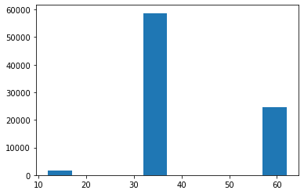

```python
def histogramme(dataframe,col,taille_bins):
    bins=np.arange(dataframe[col].min(),dataframe[col].max()+taille_bins,taille_bins)
    return plt.hist(data=dataframe,x=col,bins=bins);
histogramme(clean_loan,'Term',5);
#plt.hist(data=clean_loan,x='Term',bins=20);
```

> > **L'histogramme ici ne donne pas assez d'information pour tirer de conclusions assez précises.**

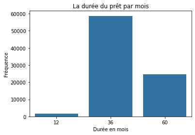

```python
# definisons une fonction pour le traçage de countplot
def diagramme_barre(dataframe,col):
    couleur=sb.color_palette()[0]
    return sb.countplot(data=dataframe,x=col,color=couleur);
diagramme_barre(clean_loan,'Term')
plt.title('La durée du prêt par mois')
plt.xlabel('Durée en mois')
plt.ylabel('Fréquence');
#sb.countplot(data=clean_loan,x='Term',color=sb.color_palette()[0]);
```

> > **Nous remarquons que la durée du prêt est de trois types à savoir 36,60 et 12**

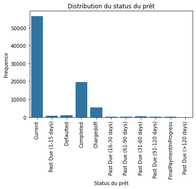

```python
diagramme_barre(clean_loan,'LoanStatus')
plt.xticks(rotation=90);
plt.title('Distribution du status du prêt')
plt.xlabel('Status du prêt')
plt.ylabel('Fréquence');
```

> > **Le prêt en cours présente la fréquence la plus élèvé pendant que les prêts en souffrance présentent une faible fréquence. Les prêt remboursés sont aussi bien représentés.**

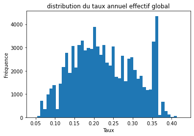

```python
histogramme(clean_loan,'BorrowerAPR',0.008)
plt.title('distribution du taux annuel effectif global')
plt.xlabel('Taux')
plt.ylabel('Fréquence');
```

> > **Le diagramme présente une variation multimodal avec des picks au niveau de 0.9,0.20,0.3 et 0.35. Représentant, selon le dictionnaire des données, le taux annuel effectif global (APR) de l'emprunteur pour le prêt. Nous remarquons que la fréquence la plus élevée se trouve au tour de 0.35.**

```python
clean_loan.BorrowerAPR.value_counts()
```

```
0.35797    3672
0.35643    1644
0.30532     902
0.29510     747
0.35356     721
           ...
0.27518       1
0.18477       1
0.29961       1
0.31400       1
0.22674       1
Name: BorrowerAPR, Length: 2330, dtype: int64
```

> > **La valeur la plus fréquente est précisement 0.35797 suivie de 0.35643.**

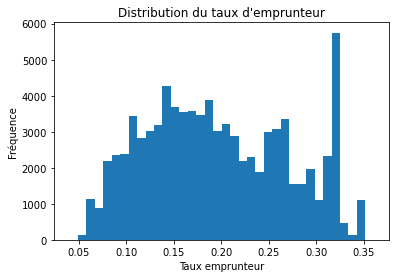

```python
histogramme(clean_loan,'BorrowerRate',0.0089);
plt.title("Distribution du taux d'emprunteur")
plt.xlabel("Taux emprunteur")
plt.ylabel("Fréquence");
```

> > **BorrowerRate représente, selon le dictionnaire des données, le taux d'intérêt de l'emprunteur pour ce prêt. Son diagramme montre une variation bimodal avec des pick dans la zone de 0.15 et de 0.32 qui est la fréquence plus élevée.**

```python
clean_loan.BorrowerRate.value_counts()
```

```
0.3177    3672
0.3199    1645
0.2699    1314
0.1099     932
0.3500     802
          ...
0.3094       1
0.1525       1
0.2125       1
0.2784       1
0.2665       1
Name: BorrowerRate, Length: 1229, dtype: int64
```

> > **La fréquence la plus élevée est précisement 0.3177 suivie de 0.3199**

[figure not shown]

```python
plt.hist(data=clean_loan, x='ProsperRating (Numeric)');
```

> > **Dificile de tirer une queleconque information à partir de ce graphe. Essayons d'analyse la version Alpha**

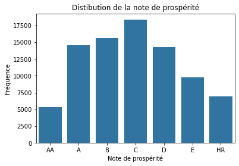

```python
# Il s'agit d'une variable categorielles ordinale
ordonnee = pd.api.types.CategoricalDtype(ordered = True, categories = ['AA', 'A', 'B', 'C', 'D', 'E', 'HR'])
clean_loan['ProsperRating (Alpha)'] = clean_loan['ProsperRating (Alpha)'].astype(ordonnee)
diagramme_barre(clean_loan,'ProsperRating (Alpha)');
plt.title("Distibution de la note de prospérité")
plt.xlabel('Note de prospérité')
plt.ylabel("Fréquence");
```

> > **La note moyenne C est la plus fréquente dans le dataset suivie de la note B. La AA (plus forte) est la moins fréquente.**

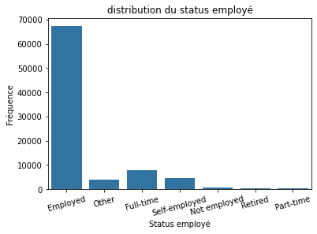

```python
diagramme_barre(clean_loan,'EmploymentStatus');
plt.xticks(rotation=15)
plt.title("distribution du status employé")
plt.xlabel("Status employé")
plt.ylabel("Fréquence");
```

> > **Le nombre des employés est clairement le plus élevé, tandis que les personnes qui travaillent en temps partiel sont le moins nombreux.**

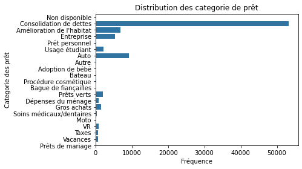

```python
#diagramme_barre(clean_loan,'ListingCategory (numeric)');
# Nous optons pour un diagramme horizontal puisque la rotation de l'axe de x ne donne pas aux categories une bonne lisibilité
sb.countplot(data=clean_loan,y='ListingCategory (numeric)',color=sb.color_palette()[0])
# Associons les categories à leurs réels sens
cats=['Non disponible','Consolidation de dettes', "Amélioration de l'habitat", 'Entreprise', 'Prêt personnel','Usage étudiant','Auto','Autre','Adoption de bébé','Bateau','Procédure cosmétique','Bague de fiançailles','Prêts verts','Dépenses du ménage','Gros achats','Soins médicaux/dentaires','Moto','VR','Taxes','Vacances','Prêts de mariage']
plt.yticks(np.arange(0,21),cats)
plt.title('Distribution des categorie de prêt')
plt.xlabel('Fréquence')
plt.ylabel('Categorie des prêt');
```

> > **Les prêts effectués pour de raison de consolidation de dettes sont de très les plus fréquents suivie de la categorie Auto puis Améliration de l'habitat, Entreprise....**

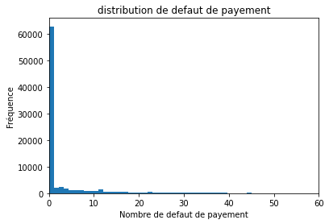

```python
histogramme(clean_loan,'DelinquenciesLast7Years',1.1)
plt.xlim(0,60)
plt.title("distribution de defaut de payement")
plt.xlabel("Nombre de defaut de payement")
plt.ylabel("Fréquence");
```

> > **Durant les 7 dernières années peu d'empreunteurs on enregistré des defauts de payements.**

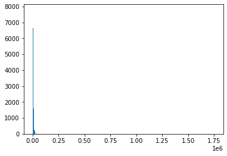

```python
histogramme(clean_loan,'StatedMonthlyIncome',500);
```

> > **Essayons de limiter l'axe des x pour rendre le graphique plus claire.**

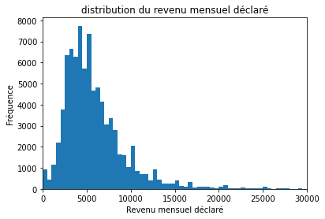

```python
histogramme(clean_loan,'StatedMonthlyIncome',500);
plt.xlim(0,30000)
plt.title("distribution du revenu mensuel déclaré")
plt.xlabel("Revenu mensuel déclaré")
plt.ylabel("Fréquence");
```

> > **Nous pouvons maintenant remarquer que la valeur la plus fréqunte est au tour de 5000.**

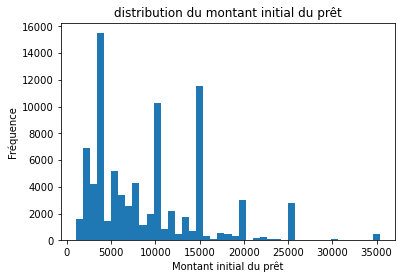

```python
histogramme(clean_loan,'LoanOriginalAmount',800);
plt.title("distribution du montant initial du prêt")
plt.xlabel("Montant initial du prêt")
plt.ylabel("Fréquence");
```

```python
clean_loan['Annee']=pd.DatetimeIndex(clean_loan['LoanOriginationDate']).year
clean_loan['Mois']=pd.DatetimeIndex(clean_loan['LoanOriginationDate']).month
```

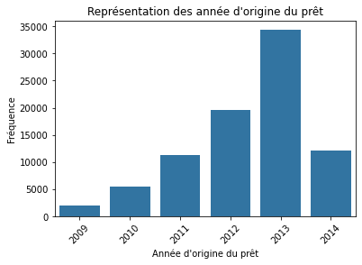

```python
diagramme_barre(clean_loan,'Annee');
plt.xticks(rotation=45)
plt.title("Représentation des année d'origine du prêt")
plt.xlabel("Année d'origine du prêt")
plt.ylabel("Fréquence");
```

> > **L'année 2013 apparait comme l'année au cours de laquelle il y'a plus de prêt, suivie de 2012.**

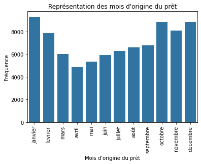

```python
diagramme_barre(clean_loan,'Mois');
mois_text=['janvier','fevrier','mars','avril','mai','juin','juillet','août','septembre','octobre','novembre','decembre']
plt.xticks(np.arange(0,12),mois_text)
plt.xticks(rotation=90)
plt.title("Représentation des mois d'origine du prêt")
plt.xlabel("Mois d'origine du prêt")
plt.ylabel("Fréquence");
```

```python
clean_loan.Mois.value_counts()
```

```
1     9315
12    8872
10    8832
11    8080
2     7846
9     6800
8     6625
7     6295
3     6032
6     5938
5     5361
4     4857
Name: Mois, dtype: int64
```

> > **Le mois de janvier présente la plus grande fréquence des prêts suivi de décembre puis octobre ensuite novembre...**

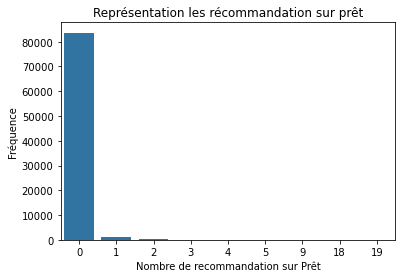

```python
diagramme_barre(clean_loan,'Recommendations')
plt.title("Représentation les récommandation sur prêt")
plt.xlabel("Nombre de recommandation sur Prêt")
plt.ylabel("Fréquence");
```

> > **Dans la plus part des cas les prêt n'ont besoin d'aucune recommandation pour être octoyés.**

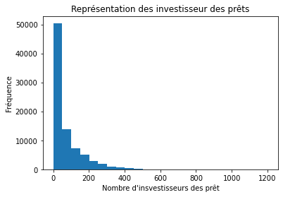

```python
histogramme(clean_loan,'Investors',50)
plt.title("Représentation des investisseur des prêts")
plt.xlabel("Nombre d'insvestisseurs des prêt")
plt.ylabel("Fréquence");
```

```python
clean_loan.Investors.value_counts()
```

```
1      27441
2       1200
3        872
4        696
5        615
       ...
779        1
559        1
695        1
585        1
618        1
Name: Investors, Length: 681, dtype: int64
```

## Bivariate Exploration

> Commençons par voir les rélations entre variables.

```python
numeric_vars = ['Term', 'BorrowerRate', 'DelinquenciesLast7Years', 'StatedMonthlyIncome','ProsperRating (numeric)','LoanOriginalAmount', 'Recommendations', 'Investors']
categoric_vars = ['LoanStatus', 'BorrowerAPR','ProsperRating (Alpha)','ListingCategory (numeric)','EmploymentStatus', 'Annee','mois']
```

Pour les variables numeriques.

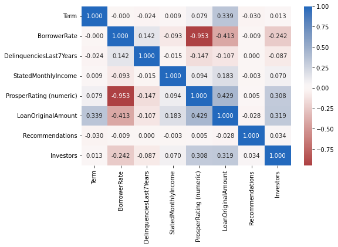

```python
# Matrix de correlation
plt.figure(figsize = [8, 5])
sb.heatmap(clean_loan[numeric_vars].corr(), annot = True, fmt = '.3f',
           cmap = 'vlag_r', center = 0)
plt.show()
```

La plus part des correlation entre variables sont faibles.

On remarque qu'en même quelque correlations moyennes entre **LoanoriginalAmount** et des variables comme **ProsperRating (numeric)**, **Term**, et **Investors**, aussi entre **Investors** et **ProsperRating (numeric)**.

On observe aussi une forte correlation negative entre **ProsperRating (numeric)** et **BorrowerRate**.

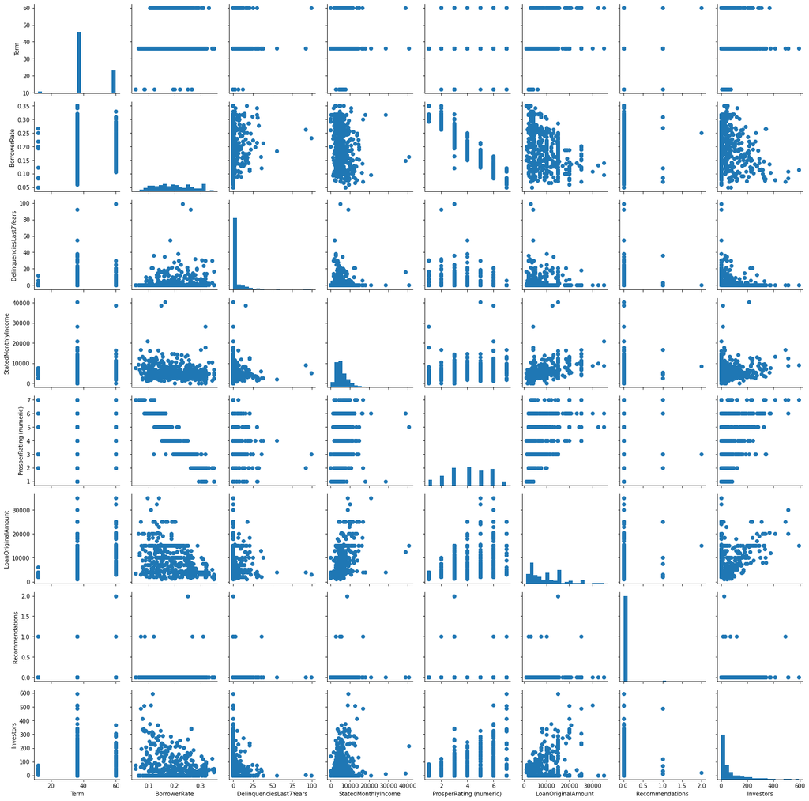

```python
g = sb.PairGrid(data = clean_loan.sample(500), vars = numeric_vars)
g = g.map_diag(plt.hist, bins = 20)
g.map_offdiag(plt.scatter);
```

[figure not shown]

```python
sb.regplot(data=clean_loan,y='Investors',x="ProsperRating (numeric)")
plt.xlabel("Nombre d'investisseurs")
plt.ylabel("Taux de prosperité")
plt.title("Distribution des investisseur selon la taux de prospérité");
```

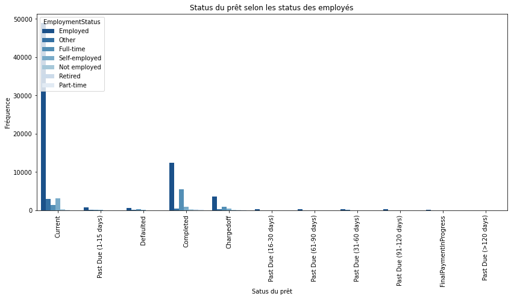

```python
plt.figure(figsize=[14,6])
sb.countplot(data = clean_loan, x = 'LoanStatus', hue = 'EmploymentStatus', palette = 'Blues_r')
plt.xticks(rotation=90)
plt.xlabel("Satus du prêt")
plt.ylabel("Fréquence")
plt.title("Status du prêt selon les status des employés");
```

Les employés detiennent les grande partie des prêts courants. Nous remaquons aussi que les travailleurs à temps plein ont une grande fréquence de remboursement.

[figure not shown]

```python
plt.scatter(data = clean_loan, x = 'ProsperRating (numeric)', y = 'LoanOriginalAmount',cmap='viridis_r')
plt.xlabel('Montant original du prêt')
plt.ylabel('Taux de prospérité')
plt.title("Relation du taux de propérité avec le montant original du prêt");
```

Nous remarquons que le taux de prosperité a tendance à croître avec la croissance du montant original du prêt.

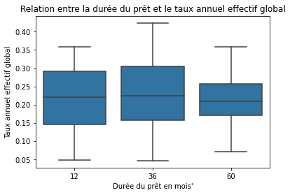

```python
sb.boxplot(data=clean_loan,x="Term",y="BorrowerAPR",color=sb.color_palette()[0])

plt.xlabel("Durée du prêt en mois'");
plt.ylabel("Taux annuel effectif global");
plt.title("Relation entre la durée du prêt et le taux annuel effectif global");
```

Le prêt à durée de 36 mois à une fréquence beaucoup plus large.

## Multivariate Exploration

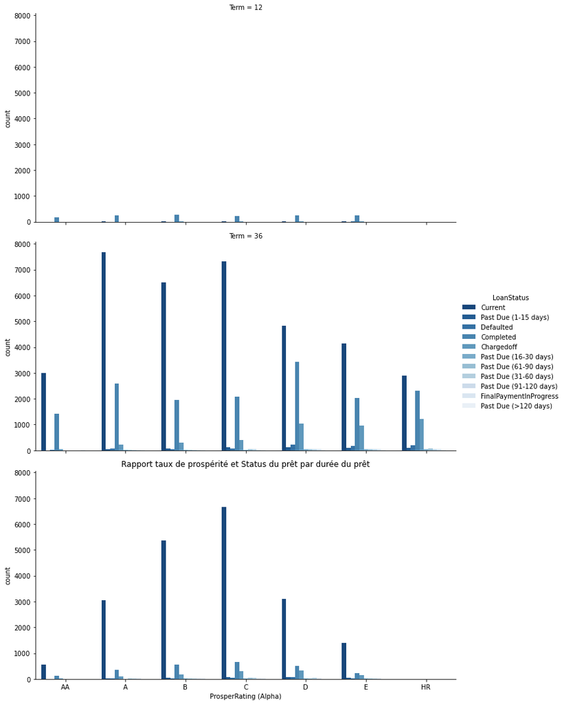

```python
sb.catplot(x='ProsperRating (Alpha)', hue='LoanStatus', col='Term',data=clean_loan, kind='count', palette='Blues_r', col_wrap=1,height=5, aspect=2)
plt.title('Rapport taux de prospérité et Status du prêt par durée du prêt');
```

Pour la durée de 36 mois le taux de prospérité de type A semble être le mieux représenté avec une domination du status de prêt Current suivie de compled.

Pour la durée de 60 mois le taux de prospérité de type C présente le pick le plus élevé pour le status de prêt de type Current et completed.

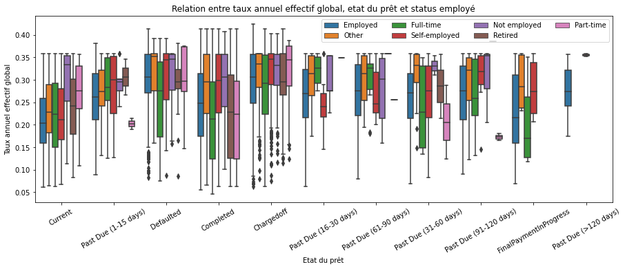

```python
plt.figure(figsize=[15,5])
sb.boxplot(data=clean_loan,x="LoanStatus",y="BorrowerAPR",hue="EmploymentStatus");
plt.xticks(rotation =30);
plt.legend(ncol=4);

plt.title("Relation entre taux annuel effectif global, etat du prêt et status employé")
plt.ylabel("Taux annuel effectif global")
plt.xlabel("Etat du prêt");
```

Les employés et les travailleurs à tant plein sont en général ceux qui ont le taux annuel effectif global le plus faible. Pour le status de prêt completed les non salariés et les indépendants ont le taux annuel effectif global le plus élevé.

```python
clean_loan.to_csv('clean_data.csv',index=False)
```

## Conclusions

# Références

- https://github.com/udacity/nd002-C4-Data_Visualization
- https://matplotlib.org/3.3.1/tutorials/introductory/sample_plots.html#sphx-glr-tutorials-introductory-sample-plots-py
- https://seaborn.pydata.org/examples/index.html
- https://matplotlib.org/stable/api/markers_api.html
- https://seaborn.pydata.org/generated/seaborn.FacetGrid.html